# Tugas Praktikum 4

Anis Sulistiyowati - G1401211084

2023-09-21

## White Noise

*White noise* dibangkitkan dari suatu peubah acak, umumnya peubah acak normal.

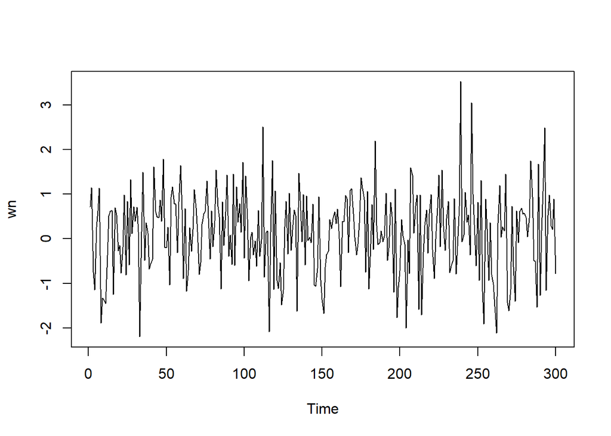

```r
set.seed(084)
wn <- rnorm(300)
ts.plot(wn)
```

Dapat terlihat bahwa *white noise* tidak memiliki autokorelasi dari ACF. Perhatikan bahwa lag ke-0 adalah korelasi observasi ke-t dengan dirinya sendiri. Nilai korelasi tersebut pasti 1. Sebagai alternatif, lag pertama di plot ACF dapat ditetapkan sebagai 1 (alih-alih 0) dengan menambahkan argumen `xlim(1, lag akhir)`. Plot tersebut dapat disandingkan bersamaan dengan membuat matriks $1 \times 2$ dengan `par(mfrow = c(1,2))`.

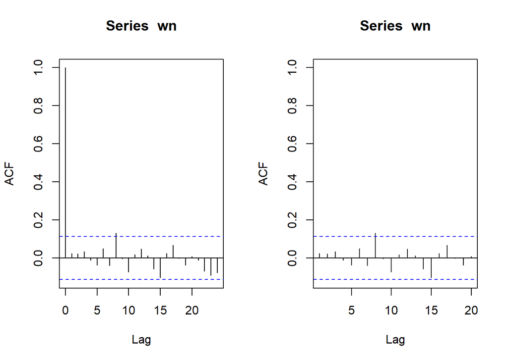

```r
par(mfrow = c(1, 2))
acf(wn)
acf(wn, xlim = c(1, 20))
```

## Proses MA

Proses MA dapat dituliskan sebagai berikut:

$$y_{t} = c + e_t + \theta_{1}e_{t-1} + \theta_{2}e_{t-2} + \dots +
\theta_{q}e_{t-q} = c+{e_t+\sum_{i=1}^p \theta_ie_{t-i}}$$
Terlihat bahwa $e_t$, atau *white noise*, berperan penting dalam pembangkitan proses MA.

## Pembangkitan Proses MA(2)

Akan dicoba membangkitkan proses MA(2) dengan $\theta_1 = 0.4$ sebanyak 300 observasi dan $c=0$. Karena diperlukan satu nilai awal untuk $e_{t-1}$ dan $e_{t-2}$, masukkan nilai pertama dan kedua white noise sebagai nilai awal tersebut.

```r
set.seed(084)
ma <- wn[c(1,2)]
```

Nilai-nilai selanjutnya dapat dicari melalui *loop*. Bentuk loop dapat dilihat dari rumus MA(2) yang hendak dibangkitkan:

```r
for(i in 3:300){
   ma[i] <- wn[i] + 0.4 * wn[i - 1]+0.6 * wn[i-2]
}
ma
```

```
##   [1]  0.719601770  1.140565360  0.142250893 -0.760373499 -0.650341642
##   [6]  0.042345185  1.534708184 -1.063138108 -1.406544841 -3.048431625
##  [11] -2.803990896 -1.786059917 -0.513449953  0.595330610  1.191972023
##  [16] -0.617934802  0.580667389  0.066182077  0.363302145  0.065342222
##  [21] -0.987161435 -0.589020582  0.443244145 -0.534683660  1.103734429
##  [26] -0.740340667  1.593508601  0.287695081  1.555026271  0.740229424
##  [31]  1.292601579  0.673328471 -1.707905322 -0.622913173  0.235748944
##  [36]  0.204922193  1.063426864 -0.022951583 -0.414210639 -0.764249313
##  [41] -1.102316100  1.081398885  0.974080995  1.704214276  1.032700264
##  [46]  1.355814061  1.022675739  2.464800221  0.758927072  0.793810715
##  [51]  0.065032397 -1.046761921  0.674069003  0.913366535  1.807176788
##  [56]  1.787567578  0.471254840  1.175217257  1.787242111  1.813737460
##  [61]  0.351642440  0.716481736 -1.438046355 -0.766474780 -0.741208294
##  [66] -0.608333336  0.238584921  1.011399348  1.255878571  1.090172167
##  [71] -0.321194212 -0.760783209 -0.362177747  0.372273186  1.033841156
```

[output cut: 45 more lines]

Selain menggunakan cara di atas, pembangkitan proses MA(2) dapat dilakukan dengan fungsi `arima.sim()` sebagai berikut.

```r
ma2 <- arima.sim(list(order=c(0,0,2), ma=c(0.4,0.6)), n=300)
ma2
```

```
## Time Series:
## Start = 1
## End = 300
## Frequency = 1
##   [1]  0.142250893 -0.760373499 -0.650341642  0.042345185  1.534708184
##   [6] -1.063138108 -1.406544841 -3.048431625 -2.803990896 -1.786059917
##  [11] -0.513449953  0.595330610  1.191972023 -0.617934802  0.580667389
##  [16]  0.066182077  0.363302145  0.065342222 -0.987161435 -0.589020582
##  [21]  0.443244145 -0.534683660  1.103734429 -0.740340667  1.593508601
##  [26]  0.287695081  1.555026271  0.740229424  1.292601579  0.673328471
##  [31] -1.707905322 -0.622913173  0.235748944  0.204922193  1.063426864
##  [36] -0.022951583 -0.414210639 -0.764249313 -1.102316100  1.081398885
##  [41]  0.974080995  1.704214276  1.032700264  1.355814061  1.022675739
##  [46]  2.464800221  0.758927072  0.793810715  0.065032397 -1.046761921
##  [51]  0.674069003  0.913366535  1.807176788  1.787567578  0.471254840
```

[output cut: 49 more lines]

### Plot Time Series

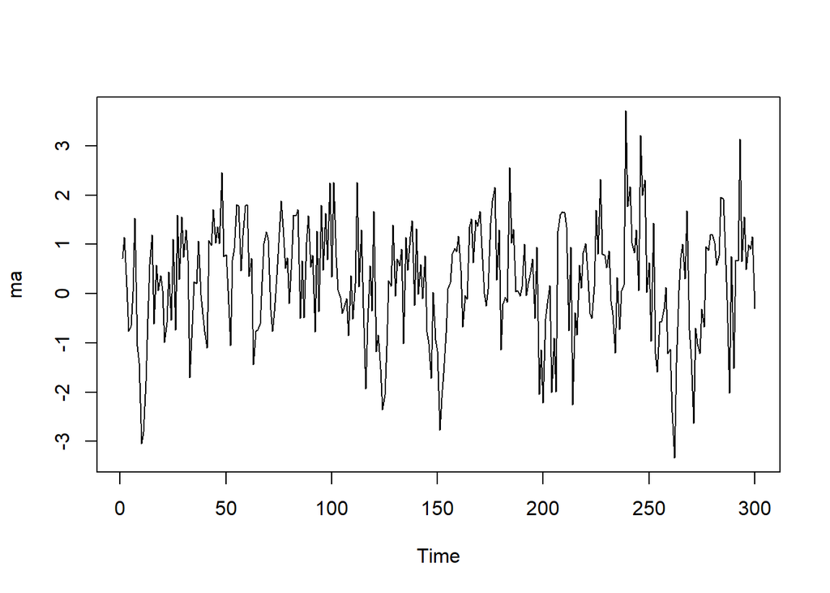

```r
ts.plot(ma)
```

Berdasarkan plot time series, terlihat bahwa data MA(2) yang dibangkitkan stasioner dalam rataan

### Plot ACF

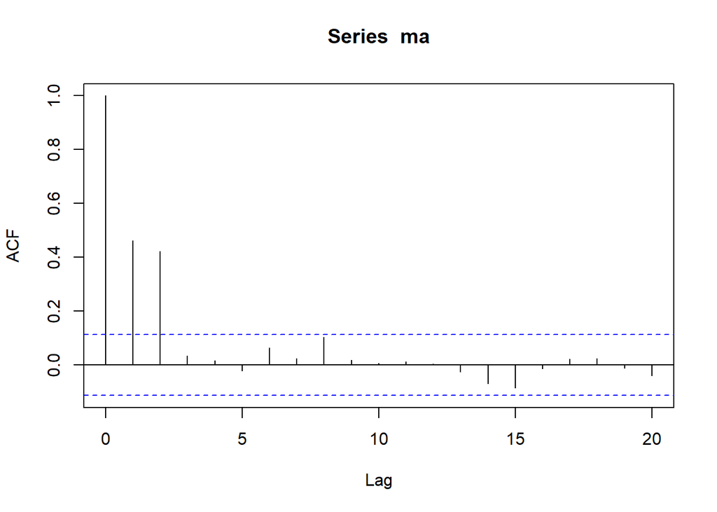

```r
acf(ma,lag.max = 20)
```

Berdasarkan plot AFC tersebut, terlihat bahwa plot ACF *cuts off* di lag kedua

### Plot PACF

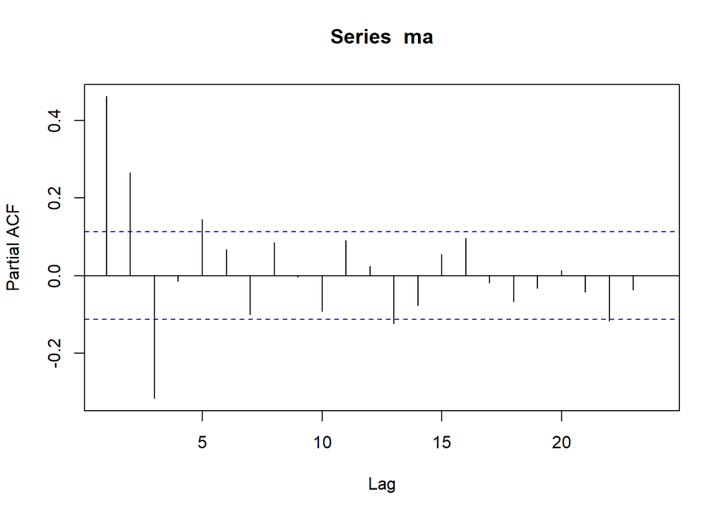

```r
pacf(ma)
```

Berdasarkan plot PACF tersebut, terlihat bahwa plot PACF cenderung *tails off* dan membentuk gelombang sinus

### Plot EACF

```r
TSA::eacf(ma)
```

```
## AR/MA
##   0 1 2 3 4 5 6 7 8 9 10 11 12 13
## 0 x x o o o o o o o o o  o  o  o
## 1 x x x o o o o o o o o  o  o  o
## 2 x x x o o o o x o o o  o  o  o
## 3 o x o o o o o x o o o  o  o  o
## 4 x x x x x o o o o o o  o  o  o
## 5 x x x x x o x x o o o  o  o  o
## 6 x x x o o o o x o o o  o  o  o
## 7 x x o x o o o x x o o  o  o  o
```

Berdasarkan pola segitiga nol pada plot EACF, terlihat bahwa segitiga nol berada pada ordo AR(0) dan ordo MA(2)

### Scatterplot Antar Lag

#### Korelasi antara $Y_t$ dengan $Y_{t-1}$

```r
#Yt
yt_ma <- ma[-1]
yt_ma
```

```
##   [1]  1.140565360  0.142250893 -0.760373499 -0.650341642  0.042345185
##   [6]  1.534708184 -1.063138108 -1.406544841 -3.048431625 -2.803990896
##  [11] -1.786059917 -0.513449953  0.595330610  1.191972023 -0.617934802
##  [16]  0.580667389  0.066182077  0.363302145  0.065342222 -0.987161435
##  [21] -0.589020582  0.443244145 -0.534683660  1.103734429 -0.740340667
##  [26]  1.593508601  0.287695081  1.555026271  0.740229424  1.292601579
##  [31]  0.673328471 -1.707905322 -0.622913173  0.235748944  0.204922193
##  [36]  1.063426864 -0.022951583 -0.414210639 -0.764249313 -1.102316100
##  [41]  1.081398885  0.974080995  1.704214276  1.032700264  1.355814061
##  [46]  1.022675739  2.464800221  0.758927072  0.793810715  0.065032397
##  [51] -1.046761921  0.674069003  0.913366535  1.807176788  1.787567578
##  [56]  0.471254840  1.175217257  1.787242111  1.813737460  0.351642440
##  [61]  0.716481736 -1.438046355 -0.766474780 -0.741208294 -0.608333336
##  [66]  0.238584921  1.011399348  1.255878571  1.090172167 -0.321194212
##  [71] -0.760783209 -0.362177747  0.372273186  1.033841156  1.882134062
```

[output cut: 45 more lines]

```r
#Yt-1
yt_1_ma <- ma[-300]
yt_1_ma
```

```
##   [1]  0.719601770  1.140565360  0.142250893 -0.760373499 -0.650341642
##   [6]  0.042345185  1.534708184 -1.063138108 -1.406544841 -3.048431625
##  [11] -2.803990896 -1.786059917 -0.513449953  0.595330610  1.191972023
##  [16] -0.617934802  0.580667389  0.066182077  0.363302145  0.065342222
##  [21] -0.987161435 -0.589020582  0.443244145 -0.534683660  1.103734429
##  [26] -0.740340667  1.593508601  0.287695081  1.555026271  0.740229424
##  [31]  1.292601579  0.673328471 -1.707905322 -0.622913173  0.235748944
##  [36]  0.204922193  1.063426864 -0.022951583 -0.414210639 -0.764249313
##  [41] -1.102316100  1.081398885  0.974080995  1.704214276  1.032700264
##  [46]  1.355814061  1.022675739  2.464800221  0.758927072  0.793810715
##  [51]  0.065032397 -1.046761921  0.674069003  0.913366535  1.807176788
##  [56]  1.787567578  0.471254840  1.175217257  1.787242111  1.813737460
##  [61]  0.351642440  0.716481736 -1.438046355 -0.766474780 -0.741208294
##  [66] -0.608333336  0.238584921  1.011399348  1.255878571  1.090172167
##  [71] -0.321194212 -0.760783209 -0.362177747  0.372273186  1.033841156
```

[output cut: 45 more lines]

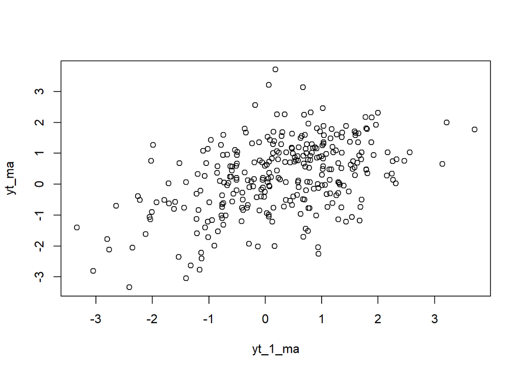

```r
plot(y=yt_ma,x=yt_1_ma)
```

Berdasarkan scatterplot tersebut, terlihat bahwa terdapat hubungan positif antara $Y_t$ dengan $Y_{t-1}$. Hal ini sesuai dengan teori yang ada

```r
cor(yt_ma,yt_1_ma)
```

```
## [1] 0.4619688
```

Korelasi antara $Y_t$ dengan $Y_{t-1}$ dari hasil simulasi mendekati perhitungan teoritis yaitu

$$\rho_1=\frac{\theta_1+\theta_1\theta_2}{1+(\theta_1)^2+(\theta_2)^2}=\frac{0.4+(0.4*0.6)}{1+0.4^2+0.6^2}=0.42$$
Tambahan: jika data yg diabngkitkan lebih banyak->semakin mendekati teoritis

#### Korelasi antara $Y_t$ dengan $Y_{t-2}$

```r
#Yt
yt_ma2 <- ma[-c(1,2)]
yt_ma2
```

```
##   [1]  0.142250893 -0.760373499 -0.650341642  0.042345185  1.534708184
##   [6] -1.063138108 -1.406544841 -3.048431625 -2.803990896 -1.786059917
##  [11] -0.513449953  0.595330610  1.191972023 -0.617934802  0.580667389
##  [16]  0.066182077  0.363302145  0.065342222 -0.987161435 -0.589020582
##  [21]  0.443244145 -0.534683660  1.103734429 -0.740340667  1.593508601
##  [26]  0.287695081  1.555026271  0.740229424  1.292601579  0.673328471
##  [31] -1.707905322 -0.622913173  0.235748944  0.204922193  1.063426864
##  [36] -0.022951583 -0.414210639 -0.764249313 -1.102316100  1.081398885
##  [41]  0.974080995  1.704214276  1.032700264  1.355814061  1.022675739
##  [46]  2.464800221  0.758927072  0.793810715  0.065032397 -1.046761921
##  [51]  0.674069003  0.913366535  1.807176788  1.787567578  0.471254840
##  [56]  1.175217257  1.787242111  1.813737460  0.351642440  0.716481736
##  [61] -1.438046355 -0.766474780 -0.741208294 -0.608333336  0.238584921
##  [66]  1.011399348  1.255878571  1.090172167 -0.321194212 -0.760783209
##  [71] -0.362177747  0.372273186  1.033841156  1.882134062  1.352071871
```

[output cut: 45 more lines]

```r
#Yt-2
yt_2_ma <- ma[-c(299,300)]
yt_2_ma
```

```
##   [1]  0.719601770  1.140565360  0.142250893 -0.760373499 -0.650341642
##   [6]  0.042345185  1.534708184 -1.063138108 -1.406544841 -3.048431625
##  [11] -2.803990896 -1.786059917 -0.513449953  0.595330610  1.191972023
##  [16] -0.617934802  0.580667389  0.066182077  0.363302145  0.065342222
##  [21] -0.987161435 -0.589020582  0.443244145 -0.534683660  1.103734429
##  [26] -0.740340667  1.593508601  0.287695081  1.555026271  0.740229424
##  [31]  1.292601579  0.673328471 -1.707905322 -0.622913173  0.235748944
##  [36]  0.204922193  1.063426864 -0.022951583 -0.414210639 -0.764249313
##  [41] -1.102316100  1.081398885  0.974080995  1.704214276  1.032700264
##  [46]  1.355814061  1.022675739  2.464800221  0.758927072  0.793810715
##  [51]  0.065032397 -1.046761921  0.674069003  0.913366535  1.807176788
##  [56]  1.787567578  0.471254840  1.175217257  1.787242111  1.813737460
##  [61]  0.351642440  0.716481736 -1.438046355 -0.766474780 -0.741208294
##  [66] -0.608333336  0.238584921  1.011399348  1.255878571  1.090172167
##  [71] -0.321194212 -0.760783209 -0.362177747  0.372273186  1.033841156
```

[output cut: 45 more lines]

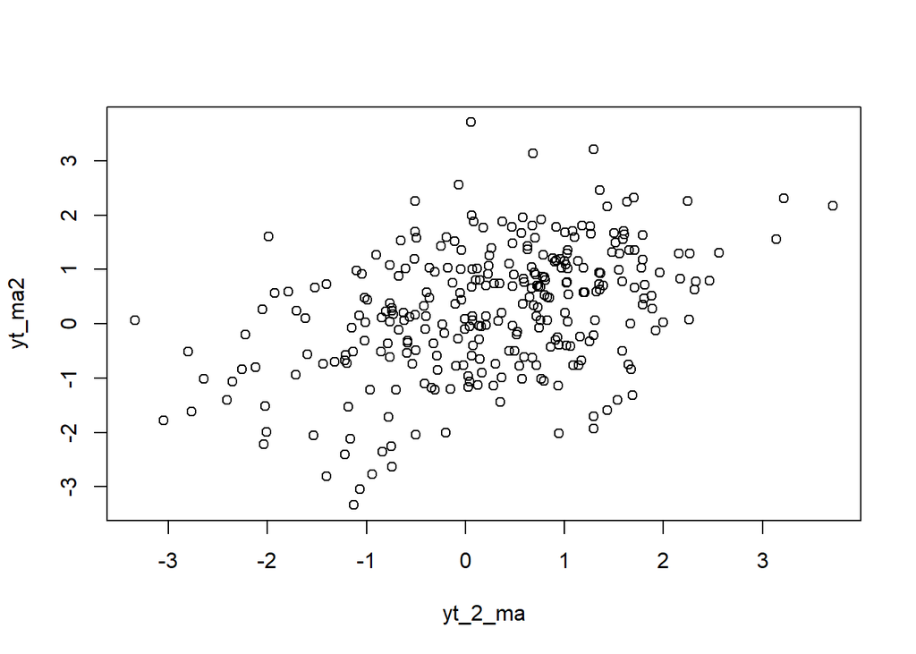

```r
plot(y=yt_ma2,x=yt_2_ma)
```

```r
cor(yt_ma2,yt_2_ma)
```

```
## [1] 0.42338
```

#### Korelasi antara $Y_t$ dengan $Y_{t-3}$

```r
#Yt
yt_ma3 <- ma[-c(1,2,3)]
yt_ma3
```

```
##   [1] -0.760373499 -0.650341642  0.042345185  1.534708184 -1.063138108
##   [6] -1.406544841 -3.048431625 -2.803990896 -1.786059917 -0.513449953
##  [11]  0.595330610  1.191972023 -0.617934802  0.580667389  0.066182077
##  [16]  0.363302145  0.065342222 -0.987161435 -0.589020582  0.443244145
##  [21] -0.534683660  1.103734429 -0.740340667  1.593508601  0.287695081
##  [26]  1.555026271  0.740229424  1.292601579  0.673328471 -1.707905322
##  [31] -0.622913173  0.235748944  0.204922193  1.063426864 -0.022951583
##  [36] -0.414210639 -0.764249313 -1.102316100  1.081398885  0.974080995
##  [41]  1.704214276  1.032700264  1.355814061  1.022675739  2.464800221
##  [46]  0.758927072  0.793810715  0.065032397 -1.046761921  0.674069003
##  [51]  0.913366535  1.807176788  1.787567578  0.471254840  1.175217257
##  [56]  1.787242111  1.813737460  0.351642440  0.716481736 -1.438046355
##  [61] -0.766474780 -0.741208294 -0.608333336  0.238584921  1.011399348
##  [66]  1.255878571  1.090172167 -0.321194212 -0.760783209 -0.362177747
##  [71]  0.372273186  1.033841156  1.882134062  1.352071871  0.514794419
```

[output cut: 45 more lines]

```r
#Yt-2
yt_3_ma <- ma[-c(298,299,300)]
yt_3_ma
```

```
##   [1]  0.719601770  1.140565360  0.142250893 -0.760373499 -0.650341642
##   [6]  0.042345185  1.534708184 -1.063138108 -1.406544841 -3.048431625
##  [11] -2.803990896 -1.786059917 -0.513449953  0.595330610  1.191972023
##  [16] -0.617934802  0.580667389  0.066182077  0.363302145  0.065342222
##  [21] -0.987161435 -0.589020582  0.443244145 -0.534683660  1.103734429
##  [26] -0.740340667  1.593508601  0.287695081  1.555026271  0.740229424
##  [31]  1.292601579  0.673328471 -1.707905322 -0.622913173  0.235748944
##  [36]  0.204922193  1.063426864 -0.022951583 -0.414210639 -0.764249313
##  [41] -1.102316100  1.081398885  0.974080995  1.704214276  1.032700264
##  [46]  1.355814061  1.022675739  2.464800221  0.758927072  0.793810715
##  [51]  0.065032397 -1.046761921  0.674069003  0.913366535  1.807176788
##  [56]  1.787567578  0.471254840  1.175217257  1.787242111  1.813737460
##  [61]  0.351642440  0.716481736 -1.438046355 -0.766474780 -0.741208294
##  [66] -0.608333336  0.238584921  1.011399348  1.255878571  1.090172167
##  [71] -0.321194212 -0.760783209 -0.362177747  0.372273186  1.033841156
```

[output cut: 45 more lines]

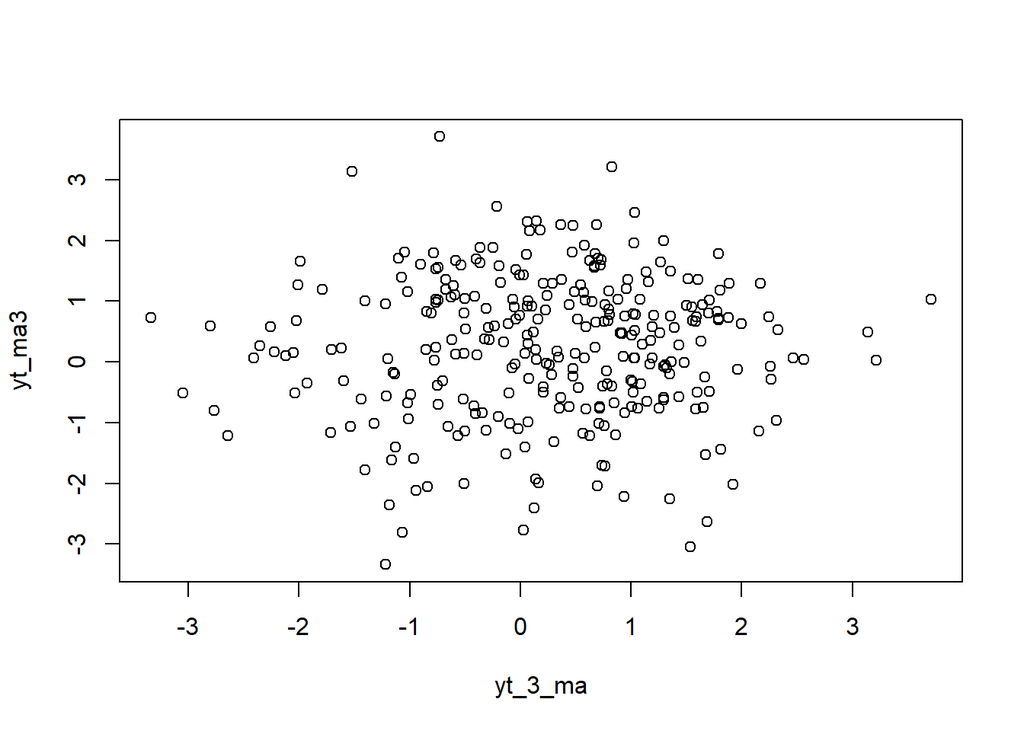

```r
plot(y=yt_ma3,x=yt_3_ma)
```

Berdasarkan scatterplot tersebut, terlihat bahwa cenderung tidak terdapat hubungan antara $Y_t$ dengan $Y_{t-3}$.

```r
cor(yt_ma3,yt_3_ma)
```

```
## [1] 0.03452371
```

Korelasi antara $Y_t$ dengan $Y_{t-3}$ hasil simulasi mendekati teori yang ada yaitu 0.

## Proses AR

Proses AR dapat dituliskan sebagai berikut:

$$y_{t} = c + e_t + \phi_{1}Y_{t-1} +
\phi_{2}Y_{t-2} + \dots + \phi_{q}Y_{t-q} = c+{e_t+\sum_{i=1}^p
\phi_iY_{t-i}}$$
Terlihat bahwa $Y_t$ berperan penting dalam pembangkitan proses AR.

## Pembangkitan Proses AR

Akan dicoba membangkitkan proses AR paling sederhana, yaitu AR(2) dengan $\phi_1 = 0.5$ dan $\phi_2 = 0.2$ sebanyak 300 observasi dan $c=0$.

```r
set.seed(084)
```

Nilai-nilai selanjutnya dapat dicari melalui *loop*. Bentuk loop dapat dilihat dari rumus AR(2) yang hendak dibangkitkan:

$$Y_t = e_t+0.5Y_{t-1}+0.2Y_{t-2}$$

```r
n<-length(wn)
n
```

```
## [1] 300
```

```r
ar <- c(1:n)
for (i in 3:n) {ar[i]<-wn[i]+0.5*ar[i-1]+0.2*ar[i-2]}
ar
```

```
##   [1]  1.000000000  2.000000000  0.454263687 -0.519286346  0.086876986
##   [6]  0.567510354  1.431266653 -1.062814620 -1.573000460 -2.381186176
##  [11] -2.959626979 -2.331063309 -1.248241690 -0.473681490  0.153292917
##  [16] -1.261928652  0.094027972  0.329380134 -0.083703174 -0.124604931
##  [21] -0.846433485 -0.641024535  0.491034134 -0.693972656  0.590968995
##  [26] -0.432779209  1.227251368  0.638267559  1.279862933  1.154984220
##  [31]  1.541939250  1.159465574 -1.307869059 -0.261058172  1.096846567
##  [36]  0.008964111  0.588807569  0.419611067 -0.354983096 -0.658847266
##  [41] -0.867095094  1.041918581  0.958731939  1.183145946  1.251146120
##  [46]  1.733647851  1.510454592  2.886529150  1.554412786  1.153956650
##  [51]  1.147681132 -0.225724781  1.046993360  1.637804456  1.813504881
##  [56]  2.012127678  1.057771528  1.764237264  2.734340635  2.377732573
##  [61]  0.839890314  1.575682166 -0.216796947 -0.498804680 -0.048183312
##  [66] -0.406691710 -0.008009000  1.013770570  1.198532581  0.955424886
##  [71] -0.081086503 -0.382881987  0.122636721  0.544951371  0.908583413
```

[output cut: 45 more lines]

Selain menggunakan cara di atas, pembangkitan proses AR dapat dilakukan dengan fungsi `arima.sim()` sebagai berikut.

```r
ar2 <- arima.sim(list(order=c(2,0,0), ar=c(0.5,0.2)), n=300)
ar2
```

```
## Time Series:
## Start = 1
## End = 300
## Frequency = 1
##   [1] -0.433412398  1.226768658  0.637899566  1.279582395  1.154770352
##   [6]  1.541776209  1.159341280 -1.307963814 -0.261130409  1.096791498
##  [11]  0.008922129  0.588775564  0.419586668 -0.355001696 -0.658861446
##  [16] -0.867105904  1.041910340  0.958725657  1.183141157  1.251142469
##  [21]  1.733645067  1.510452470  2.886527532  1.554411553  1.153955710
##  [26]  1.147680416 -0.225725327  1.046992944  1.637804138  1.813504639
##  [31]  2.012127493  1.057771388  1.764237157  2.734340554  2.377732511
##  [36]  0.839890266  1.575682130 -0.216796974 -0.498804701 -0.048183328
##  [41] -0.406691723 -0.008009009  1.013770563  1.198532575  0.955424881
##  [46] -0.081086506 -0.382881990  0.122636719  0.544951369  0.908583412
##  [51]  1.864658244  1.578618940  0.710380525  1.297677894  0.616420978
```

[output cut: 49 more lines]

## Karakteristik AR(2)

### Plot Time Series

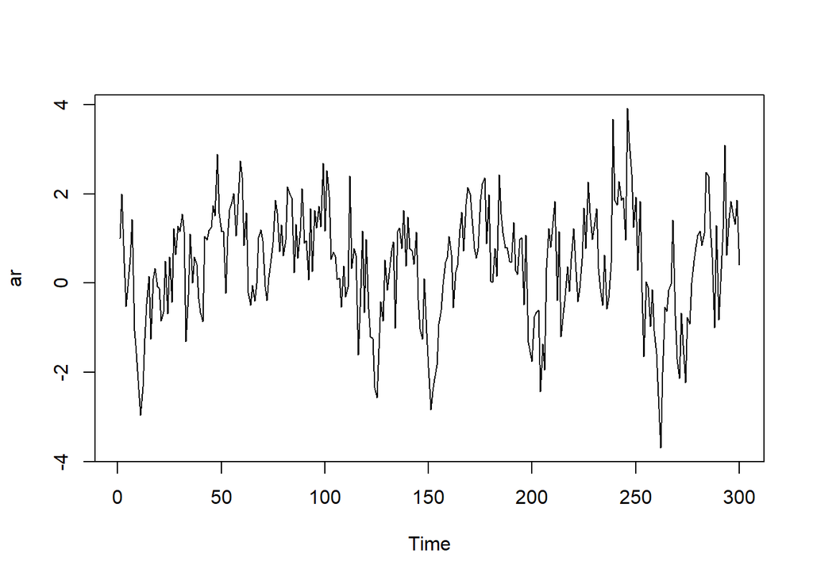

```r
ts.plot(ar)
```

Berdasarkan plot time series tersebut terlihat bahwa data cenderung stasioner pada rataan

### Plot ACF

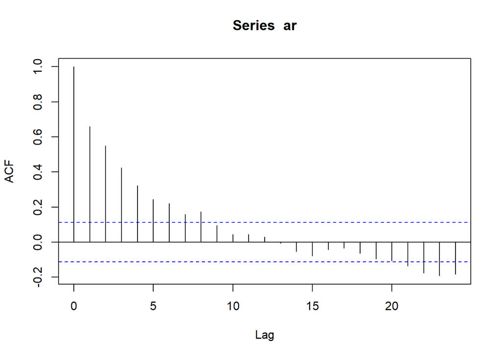

```r
acf(ar)
```

Berdasarkan plot ACF tersebut terlihat bahwa plot ACF cenderung *tails off* (turun perlahan) dan cenderung membentuk pola grafik sinus

### Plot PACF

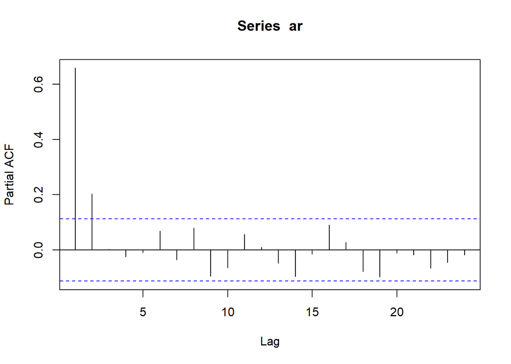

```r
pacf(ar)
```

Berdasarkan plot PACF tersebut, terlihat bahwa plot PACF *cuts off* pada lag kedua, sejalan dengan teori yang ada

### Plot EACF

```r
TSA::eacf(ar)
```

```
## AR/MA
##   0 1 2 3 4 5 6 7 8 9 10 11 12 13
## 0 x x x x x x x x o o o  o  o  o
## 1 x o o o o o o x o o o  o  o  o
## 2 o o o o o o o x o o o  o  o  o
## 3 o x o o o o o x o o o  o  o  o
## 4 x x o o o o o x o o o  o  o  o
## 5 x x x x o o o x o o o  o  o  o
## 6 x x x x o o o x o o o  o  o  o
## 7 x x x x o o o o o o o  o  o  o
```

Berdasarkan pola segitiga nol pada plot EACF, terlihat bahwa segitiga nol berada pada ordo AR(2) dan ordo MA(1)

### Scatterplot Antar Lag

#### Korelasi antara $Y_t$ dengan $Y_{t-1}$

```r
#Yt
yt_ar <- ar[-1]
yt_ar
```

```
##   [1]  2.000000000  0.454263687 -0.519286346  0.086876986  0.567510354
##   [6]  1.431266653 -1.062814620 -1.573000460 -2.381186176 -2.959626979
##  [11] -2.331063309 -1.248241690 -0.473681490  0.153292917 -1.261928652
##  [16]  0.094027972  0.329380134 -0.083703174 -0.124604931 -0.846433485
##  [21] -0.641024535  0.491034134 -0.693972656  0.590968995 -0.432779209
##  [26]  1.227251368  0.638267559  1.279862933  1.154984220  1.541939250
##  [31]  1.159465574 -1.307869059 -0.261058172  1.096846567  0.008964111
##  [36]  0.588807569  0.419611067 -0.354983096 -0.658847266 -0.867095094
##  [41]  1.041918581  0.958731939  1.183145946  1.251146120  1.733647851
##  [46]  1.510454592  2.886529150  1.554412786  1.153956650  1.147681132
##  [51] -0.225724781  1.046993360  1.637804456  1.813504881  2.012127678
##  [56]  1.057771528  1.764237264  2.734340635  2.377732573  0.839890314
##  [61]  1.575682166 -0.216796947 -0.498804680 -0.048183312 -0.406691710
##  [66] -0.008009000  1.013770570  1.198532581  0.955424886 -0.081086503
##  [71] -0.382881987  0.122636721  0.544951371  0.908583413  1.864658245
```

[output cut: 45 more lines]

```r
#Yt-1
yt_1_ar <- ar[-300]
yt_1_ar
```

```
##   [1]  1.000000000  2.000000000  0.454263687 -0.519286346  0.086876986
##   [6]  0.567510354  1.431266653 -1.062814620 -1.573000460 -2.381186176
##  [11] -2.959626979 -2.331063309 -1.248241690 -0.473681490  0.153292917
##  [16] -1.261928652  0.094027972  0.329380134 -0.083703174 -0.124604931
##  [21] -0.846433485 -0.641024535  0.491034134 -0.693972656  0.590968995
##  [26] -0.432779209  1.227251368  0.638267559  1.279862933  1.154984220
##  [31]  1.541939250  1.159465574 -1.307869059 -0.261058172  1.096846567
##  [36]  0.008964111  0.588807569  0.419611067 -0.354983096 -0.658847266
##  [41] -0.867095094  1.041918581  0.958731939  1.183145946  1.251146120
##  [46]  1.733647851  1.510454592  2.886529150  1.554412786  1.153956650
##  [51]  1.147681132 -0.225724781  1.046993360  1.637804456  1.813504881
##  [56]  2.012127678  1.057771528  1.764237264  2.734340635  2.377732573
##  [61]  0.839890314  1.575682166 -0.216796947 -0.498804680 -0.048183312
##  [66] -0.406691710 -0.008009000  1.013770570  1.198532581  0.955424886
##  [71] -0.081086503 -0.382881987  0.122636721  0.544951371  0.908583413
```

[output cut: 45 more lines]

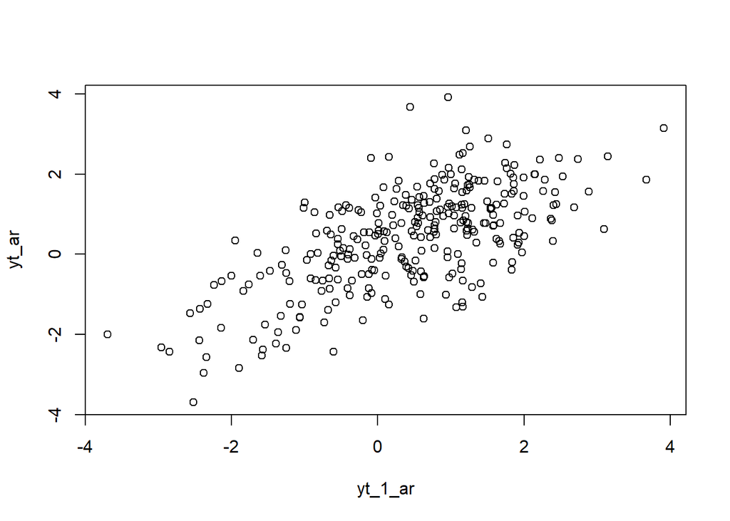

```r
plot(y=yt_ar,x=yt_1_ar)
```

Berdasarkan scatterplot tersebut, terlihat bahwa terdapat hubungan positif antara $Y_t$ dengan $Y_{t-1}$. Hal ini sesuai dengan teori yang ada

```r
cor(yt_ar,yt_1_ar)
```

```
## [1] 0.6592934
```

Korelasi antara $Y_t$ dengan $Y_{t-1}$ dari hasil simulasi mendekati perhitungan teoritis yaitu $\rho_1=\frac{\phi_1}{1-\phi_2}=\frac{0.5}{1-0.2}=0.626$

#### Korelasi antara $Y_t$ dengan $Y_{t-2}$

```r
#Yt
yt_ar2 <- ar[-c(1,2)]
yt_ar2
```

```
##   [1]  0.454263687 -0.519286346  0.086876986  0.567510354  1.431266653
##   [6] -1.062814620 -1.573000460 -2.381186176 -2.959626979 -2.331063309
##  [11] -1.248241690 -0.473681490  0.153292917 -1.261928652  0.094027972
##  [16]  0.329380134 -0.083703174 -0.124604931 -0.846433485 -0.641024535
##  [21]  0.491034134 -0.693972656  0.590968995 -0.432779209  1.227251368
##  [26]  0.638267559  1.279862933  1.154984220  1.541939250  1.159465574
##  [31] -1.307869059 -0.261058172  1.096846567  0.008964111  0.588807569
##  [36]  0.419611067 -0.354983096 -0.658847266 -0.867095094  1.041918581
##  [41]  0.958731939  1.183145946  1.251146120  1.733647851  1.510454592
##  [46]  2.886529150  1.554412786  1.153956650  1.147681132 -0.225724781
##  [51]  1.046993360  1.637804456  1.813504881  2.012127678  1.057771528
##  [56]  1.764237264  2.734340635  2.377732573  0.839890314  1.575682166
##  [61] -0.216796947 -0.498804680 -0.048183312 -0.406691710 -0.008009000
##  [66]  1.013770570  1.198532581  0.955424886 -0.081086503 -0.382881987
##  [71]  0.122636721  0.544951371  0.908583413  1.864658245  1.578618940
```

[output cut: 45 more lines]

```r
#Yt-2
yt_2_ar <- ar[-c(299,300)]
yt_2_ar
```

```
##   [1]  1.000000000  2.000000000  0.454263687 -0.519286346  0.086876986
##   [6]  0.567510354  1.431266653 -1.062814620 -1.573000460 -2.381186176
##  [11] -2.959626979 -2.331063309 -1.248241690 -0.473681490  0.153292917
##  [16] -1.261928652  0.094027972  0.329380134 -0.083703174 -0.124604931
##  [21] -0.846433485 -0.641024535  0.491034134 -0.693972656  0.590968995
##  [26] -0.432779209  1.227251368  0.638267559  1.279862933  1.154984220
##  [31]  1.541939250  1.159465574 -1.307869059 -0.261058172  1.096846567
##  [36]  0.008964111  0.588807569  0.419611067 -0.354983096 -0.658847266
##  [41] -0.867095094  1.041918581  0.958731939  1.183145946  1.251146120
##  [46]  1.733647851  1.510454592  2.886529150  1.554412786  1.153956650
##  [51]  1.147681132 -0.225724781  1.046993360  1.637804456  1.813504881
##  [56]  2.012127678  1.057771528  1.764237264  2.734340635  2.377732573
##  [61]  0.839890314  1.575682166 -0.216796947 -0.498804680 -0.048183312
##  [66] -0.406691710 -0.008009000  1.013770570  1.198532581  0.955424886
##  [71] -0.081086503 -0.382881987  0.122636721  0.544951371  0.908583413
```

[output cut: 45 more lines]

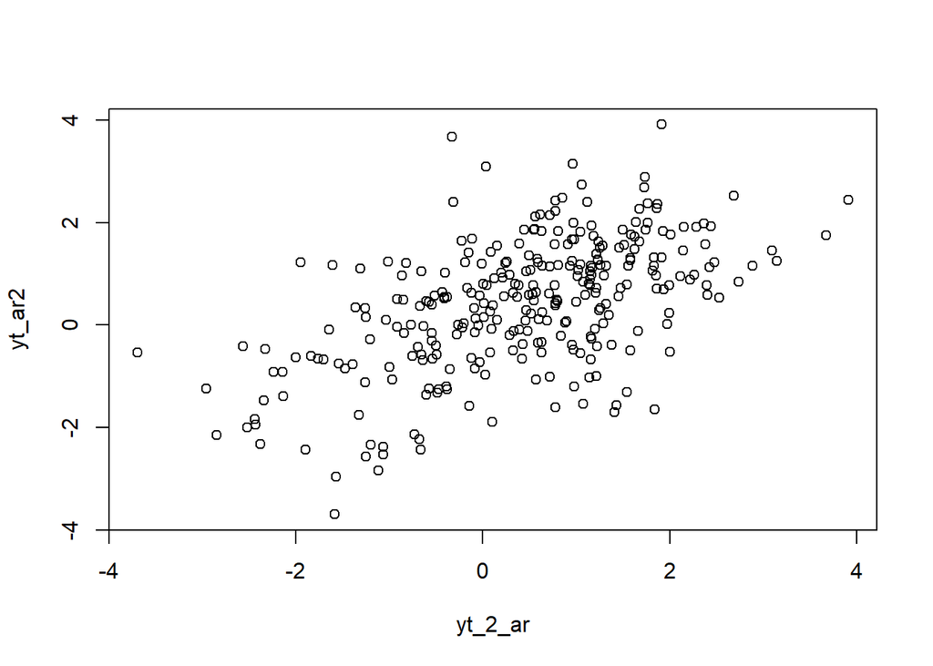

```r
plot(y=yt_ar2,x=yt_2_ar)
```

Berdasarkan scatterplot tersebut, terlihat bahwa terdapat hubungan positif antara $Y_t$ dengan $Y_{t-2}$. Hal ini sesuai dengan teori yang ada

```r
cor(yt_ar2,yt_2_ar)
```

```
## [1] 0.5521515
```

Korelasi antara $Y_t$ dengan $Y_{t-2}$ dari hasil simulasi mendekati perhitungan teoritis yaitu $\rho_1=\frac{\phi_1^2}{1-\phi_2}+\phi_2=\frac{0.5^2}{1-0.2}+0.2=0.5125$

#### Korelasi antara $Y_t$ dengan $Y_{t-3}$

```r
#Yt
yt_ar3 <- ar[-c(1,2,3)]
yt_ar3
```

```
##   [1] -0.519286346  0.086876986  0.567510354  1.431266653 -1.062814620
##   [6] -1.573000460 -2.381186176 -2.959626979 -2.331063309 -1.248241690
##  [11] -0.473681490  0.153292917 -1.261928652  0.094027972  0.329380134
##  [16] -0.083703174 -0.124604931 -0.846433485 -0.641024535  0.491034134
##  [21] -0.693972656  0.590968995 -0.432779209  1.227251368  0.638267559
##  [26]  1.279862933  1.154984220  1.541939250  1.159465574 -1.307869059
##  [31] -0.261058172  1.096846567  0.008964111  0.588807569  0.419611067
##  [36] -0.354983096 -0.658847266 -0.867095094  1.041918581  0.958731939
##  [41]  1.183145946  1.251146120  1.733647851  1.510454592  2.886529150
##  [46]  1.554412786  1.153956650  1.147681132 -0.225724781  1.046993360
##  [51]  1.637804456  1.813504881  2.012127678  1.057771528  1.764237264
##  [56]  2.734340635  2.377732573  0.839890314  1.575682166 -0.216796947
##  [61] -0.498804680 -0.048183312 -0.406691710 -0.008009000  1.013770570
##  [66]  1.198532581  0.955424886 -0.081086503 -0.382881987  0.122636721
##  [71]  0.544951371  0.908583413  1.864658245  1.578618940  0.710380525
```

[output cut: 45 more lines]

```r
#Yt-3
yt_3_ar <- ar[-c(288,299,300)]
yt_3_ar
```

```
##   [1]  1.000000000  2.000000000  0.454263687 -0.519286346  0.086876986
##   [6]  0.567510354  1.431266653 -1.062814620 -1.573000460 -2.381186176
##  [11] -2.959626979 -2.331063309 -1.248241690 -0.473681490  0.153292917
##  [16] -1.261928652  0.094027972  0.329380134 -0.083703174 -0.124604931
##  [21] -0.846433485 -0.641024535  0.491034134 -0.693972656  0.590968995
##  [26] -0.432779209  1.227251368  0.638267559  1.279862933  1.154984220
##  [31]  1.541939250  1.159465574 -1.307869059 -0.261058172  1.096846567
##  [36]  0.008964111  0.588807569  0.419611067 -0.354983096 -0.658847266
##  [41] -0.867095094  1.041918581  0.958731939  1.183145946  1.251146120
##  [46]  1.733647851  1.510454592  2.886529150  1.554412786  1.153956650
##  [51]  1.147681132 -0.225724781  1.046993360  1.637804456  1.813504881
##  [56]  2.012127678  1.057771528  1.764237264  2.734340635  2.377732573
##  [61]  0.839890314  1.575682166 -0.216796947 -0.498804680 -0.048183312
##  [66] -0.406691710 -0.008009000  1.013770570  1.198532581  0.955424886
##  [71] -0.081086503 -0.382881987  0.122636721  0.544951371  0.908583413
```

[output cut: 45 more lines]

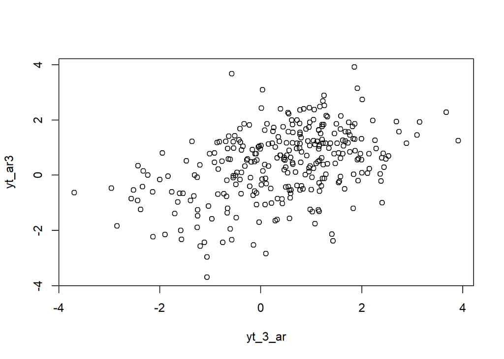

```r
plot(y=yt_ar3,x=yt_3_ar)
```

Berdasarkan scatterplot tersebut, terlihat bahwa terdapat hubungan positif antara $Y_t$ dengan $Y_{t-3}$. Hal ini sesuai dengan teori yang ada

```r
cor(yt_ar3,yt_3_ar)
```

```
## [1] 0.4255229
```

Korelasi antara $Y_t$ dengan $Y_{t-2}$ dari hasil simulasi mendekati perhitungan teoritis yaitu $\rho_1=\frac{\phi_1^3+\phi_1\phi_2}{1-\phi_2}+\phi_1\phi_2=\frac{0.5^3+(0.5)(0.2)}{1-0.2}+(0.5)(0.2)=0.38125$

## Fungsi pembangkitan ARMA

```r
set.seed(084)
n = length(wn)
phi1 = 0.5
phi2 = 0.2

theta1 = 0.4
theta2 = 0.6

y.arma=c(1:n)
for (i in 5:n){y.arma[i] = phi1*y.arma[i-1] +phi2*y.arma[i-2] + theta1*wn[i-1] + phi2*y.arma[i-2]+wn[i]}
y.arma
```

```
##   [1]  1.00000000  2.00000000  3.00000000  4.00000000  2.99710015  3.82874617
##   [7]  4.49452087  2.33886332  0.88261352 -0.53640953 -1.92244236 -2.13257109
##  [13] -1.47605217 -0.77071636 -0.08933624 -1.34088068 -0.50937664  0.02144477
##  [19] -0.24632636 -0.37009417 -1.11041976 -1.20309051 -0.14203478 -0.97120517
##  [25] -0.02718193 -0.65564281  0.75096533  0.75460212  1.43744516  1.69407422
##  [31]  2.28544943  2.26124333 -0.08818862  0.14299039  1.58956251  0.96030966
##  [37]  1.28603702  1.29653931  0.52950010 -0.05493221 -0.50845208  1.14436672
##  [43]  1.62288843  2.00906383  2.31967255  3.02203811  3.18086776  4.74118198
##  [49]  4.16582430  3.70245229  3.69715389  2.40312928  3.19860305  4.09213378
##  [55]  4.57449318  5.01599604  4.33792775  4.88389094  6.15095465  6.34301558
##  [61]  4.99913147  5.35862482  3.77842511  2.85807341  2.90276811  2.40960566
##  [67]  2.45774795  3.37381906  3.80290317  3.68168333  2.62485926  1.93227706
##  [73]  2.13300777  2.53174212  2.95473831  4.03607442  4.18505618  3.44092652
##  [79]  3.84050534  3.37283474  3.55233501  4.82893785  5.18019010  5.30041987
##  [85]  3.78717789  4.38773093  3.89362509  4.24809734  5.35014711  4.55307571
```

[output cut: 35 more lines]

### Pembangkitan Proses ARMA(2,2) manual dengan fungsi arima.sim

```r
arma22 <- arima.sim(list(order=c(2,0,2), ar = c(0.5,0.2), ma =c(0.4,0.6)), n=300)
arma22
```

```
## Time Series:
## Start = 1
## End = 300
## Frequency = 1
##   [1]  0.86729036  2.26983582  2.04860540  2.77087144  2.46848527  0.08051160
##   [7] -0.08896032  0.20737111  0.29081568  1.25030893  0.66036602  0.16603416
##  [13] -0.54915903 -1.34368878  0.29972269  0.85520458  2.19176110  2.29962173
##  [19]  2.94397715  2.95458866  4.53088998  3.61528979  3.50763361  2.54190716
##  [25]  0.92571838  1.64530963  1.92116502  3.09682123  3.72021120  2.95072468
##  [31]  3.39462184  4.07469797  4.53001081  3.43158744  3.33827762  0.91740994
##  [37]  0.35988571 -0.37778345 -0.72524792 -0.19959573  0.76655190  1.59923538
##  [43]  2.04310024  1.02020298  0.15793833 -0.07916799  0.36427686  1.20014599
##  [49]  2.55506243  2.86963228  2.46062305  2.52900147  1.56172045  1.99243433
##  [55]  2.90750126  3.43673255  4.00491492  2.19104871  2.56319006  1.22654492
##  [61]  2.16774665  2.91050629  2.43021091  2.57980915  0.99456172  2.27583775
```

[output cut: 39 more lines]

## Karakteristik ARMA(2,2)

### Plot Time Series

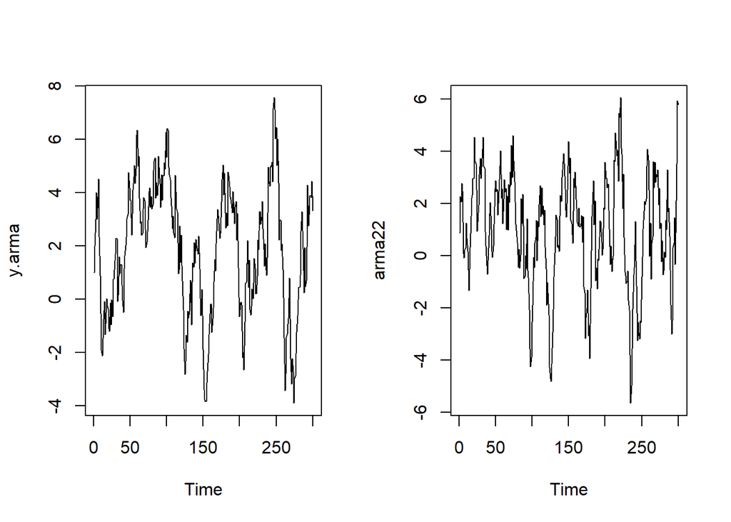

```r
par(mfrow = c(1, 2))
ts.plot(y.arma)
ts.plot(arma22)
```

```r
par(mfrow = c(1, 1))
```

Berdasarkan plot time series tersebut, terlihat bahwa model ARMA(2,2) cenderung stasioner dalam rataan

### Plot ACF

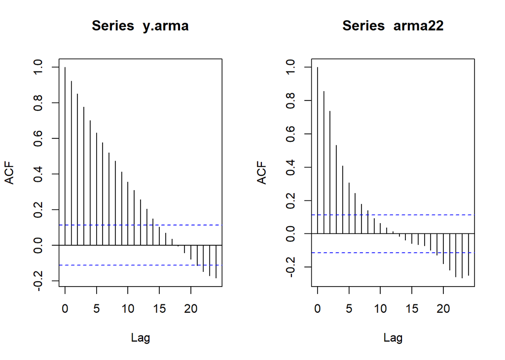

```r
par(mfrow = c(1, 2))
acf(y.arma)
acf(arma22)
```

```r
par(mfrow = c(1, 1))
```

Berdasarkan plot ACF tersebut, terlihat bahwa model ARMA(2,2) hasil simulasi memiliki plot ACF yang *tails off*, sesuai dengan teori yang ada

### Plot PACF

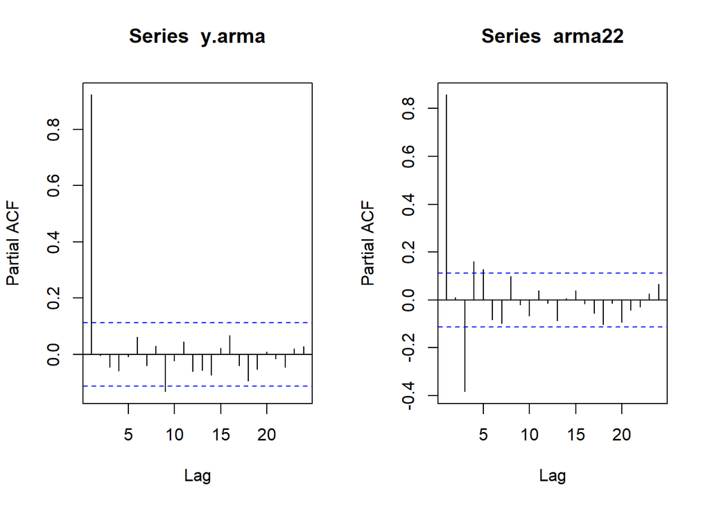

```r
par(mfrow = c(1, 2))
pacf(y.arma)
pacf(arma22)
```

```r
par(mfrow = c(1, 1))
```

### Plot EACF

```r
TSA::eacf(y.arma)
```

```
## AR/MA
##   0 1 2 3 4 5 6 7 8 9 10 11 12 13
## 0 x x x x x x x x x x x  x  x  x
## 1 o o o o o o o x o o o  o  o  o
## 2 o o o o o o o x o o o  o  o  o
## 3 x x o o o o o x o o o  o  o  o
## 4 o x o o o o o x o o o  o  o  o
## 5 o x x x o o o x o o o  o  o  o
## 6 x o o o x o o o o o o  o  o  o
## 7 x o x o x x o x o o o  o  o  o
```

```r
TSA::eacf(arma22)
```

```
## AR/MA
##   0 1 2 3 4 5 6 7 8 9 10 11 12 13
## 0 x x x x x x x x o o o  o  o  o
## 1 o x x o o o o o o o o  o  o  o
## 2 o x o o o o o o o o o  o  o  o
## 3 x x x o o o o x o o o  o  o  o
## 4 x x x o x o o x o o o  o  o  o
## 5 x x x o x o o o o o o  o  o  o
## 6 x x x x o o o o o o o  o  o  o
## 7 x o x x o x o o o o o  o  o  o
```

Berdasarkan pola segitiga nol pada plot EACF, terlihat bahwa segitiga nol berada pada ordo AR(2) dan ordo MA(2)

### Scatterplot Antar Lag

#### Korelasi antara $Y_t$ dengan $Y_{t-1}$

```r
#Yt
yt_arma <- arma22[-1]
yt_arma
```

```
##   [1]  2.26983582  2.04860540  2.77087144  2.46848527  0.08051160 -0.08896032
##   [7]  0.20737111  0.29081568  1.25030893  0.66036602  0.16603416 -0.54915903
##  [13] -1.34368878  0.29972269  0.85520458  2.19176110  2.29962173  2.94397715
##  [19]  2.95458866  4.53088998  3.61528979  3.50763361  2.54190716  0.92571838
##  [25]  1.64530963  1.92116502  3.09682123  3.72021120  2.95072468  3.39462184
##  [31]  4.07469797  4.53001081  3.43158744  3.33827762  0.91740994  0.35988571
##  [37] -0.37778345 -0.72524792 -0.19959573  0.76655190  1.59923538  2.04310024
##  [43]  1.02020298  0.15793833 -0.07916799  0.36427686  1.20014599  2.55506243
##  [49]  2.86963228  2.46062305  2.52900147  1.56172045  1.99243433  2.90750126
##  [55]  3.43673255  4.00491492  2.19104871  2.56319006  1.22654492  2.16774665
##  [61]  2.91050629  2.43021091  2.57980915  0.99456172  2.27583775  0.97250839
##  [67]  2.73117575  2.03632154  3.19687834  2.69176105  4.22737770  2.99683807
##  [73]  4.60438773  3.64568771  2.82092587  2.06121940  1.19210313  0.73000077
##  [79]  0.50069417 -0.45388615  0.23601881 -0.48447030  0.01288082  2.17251217
##  [85]  1.22657850  2.34508754  1.13232799 -0.89194662 -0.80375510 -0.01571585
```

[output cut: 35 more lines]

```r
#Yt-1
yt_1_arma <- arma22[-300]
yt_1_arma
```

```
##   [1]  0.86729036  2.26983582  2.04860540  2.77087144  2.46848527  0.08051160
##   [7] -0.08896032  0.20737111  0.29081568  1.25030893  0.66036602  0.16603416
##  [13] -0.54915903 -1.34368878  0.29972269  0.85520458  2.19176110  2.29962173
##  [19]  2.94397715  2.95458866  4.53088998  3.61528979  3.50763361  2.54190716
##  [25]  0.92571838  1.64530963  1.92116502  3.09682123  3.72021120  2.95072468
##  [31]  3.39462184  4.07469797  4.53001081  3.43158744  3.33827762  0.91740994
##  [37]  0.35988571 -0.37778345 -0.72524792 -0.19959573  0.76655190  1.59923538
##  [43]  2.04310024  1.02020298  0.15793833 -0.07916799  0.36427686  1.20014599
##  [49]  2.55506243  2.86963228  2.46062305  2.52900147  1.56172045  1.99243433
##  [55]  2.90750126  3.43673255  4.00491492  2.19104871  2.56319006  1.22654492
##  [61]  2.16774665  2.91050629  2.43021091  2.57980915  0.99456172  2.27583775
##  [67]  0.97250839  2.73117575  2.03632154  3.19687834  2.69176105  4.22737770
##  [73]  2.99683807  4.60438773  3.64568771  2.82092587  2.06121940  1.19210313
##  [79]  0.73000077  0.50069417 -0.45388615  0.23601881 -0.48447030  0.01288082
##  [85]  2.17251217  1.22657850  2.34508754  1.13232799 -0.89194662 -0.80375510
```

[output cut: 35 more lines]

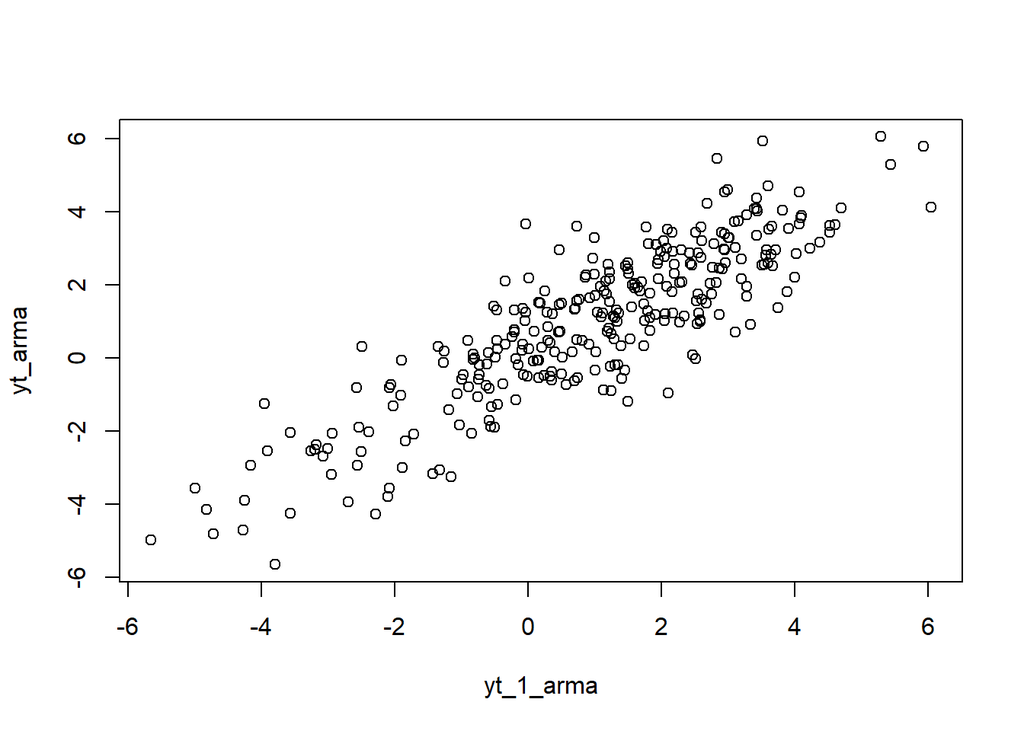

```r
plot(y=yt_arma,x=yt_1_arma)
```

Berdasarkan scatterplot tersebut, terlihat bahwa terdapat hubungan positif antara $Y_t$ dengan $Y_{t-1}$.

```r
cor(yt_arma,yt_1_arma)
```

```
## [1] 0.8644504
```

#### Korelasi antara $Y_t$ dengan $Y_{t-2}$

```r
#Yt
yt_arma2 <- arma22[-c(1,2)]
yt_arma2
```

```
##   [1]  2.04860540  2.77087144  2.46848527  0.08051160 -0.08896032  0.20737111
##   [7]  0.29081568  1.25030893  0.66036602  0.16603416 -0.54915903 -1.34368878
##  [13]  0.29972269  0.85520458  2.19176110  2.29962173  2.94397715  2.95458866
##  [19]  4.53088998  3.61528979  3.50763361  2.54190716  0.92571838  1.64530963
##  [25]  1.92116502  3.09682123  3.72021120  2.95072468  3.39462184  4.07469797
##  [31]  4.53001081  3.43158744  3.33827762  0.91740994  0.35988571 -0.37778345
##  [37] -0.72524792 -0.19959573  0.76655190  1.59923538  2.04310024  1.02020298
##  [43]  0.15793833 -0.07916799  0.36427686  1.20014599  2.55506243  2.86963228
##  [49]  2.46062305  2.52900147  1.56172045  1.99243433  2.90750126  3.43673255
##  [55]  4.00491492  2.19104871  2.56319006  1.22654492  2.16774665  2.91050629
##  [61]  2.43021091  2.57980915  0.99456172  2.27583775  0.97250839  2.73117575
##  [67]  2.03632154  3.19687834  2.69176105  4.22737770  2.99683807  4.60438773
##  [73]  3.64568771  2.82092587  2.06121940  1.19210313  0.73000077  0.50069417
##  [79] -0.45388615  0.23601881 -0.48447030  0.01288082  2.17251217  1.22657850
##  [85]  2.34508754  1.13232799 -0.89194662 -0.80375510 -0.01571585 -0.51431008
```

[output cut: 35 more lines]

```r
#Yt-2
yt_2_arma <- arma22[-c(299,300)]
yt_2_arma
```

```
##   [1]  0.86729036  2.26983582  2.04860540  2.77087144  2.46848527  0.08051160
##   [7] -0.08896032  0.20737111  0.29081568  1.25030893  0.66036602  0.16603416
##  [13] -0.54915903 -1.34368878  0.29972269  0.85520458  2.19176110  2.29962173
##  [19]  2.94397715  2.95458866  4.53088998  3.61528979  3.50763361  2.54190716
##  [25]  0.92571838  1.64530963  1.92116502  3.09682123  3.72021120  2.95072468
##  [31]  3.39462184  4.07469797  4.53001081  3.43158744  3.33827762  0.91740994
##  [37]  0.35988571 -0.37778345 -0.72524792 -0.19959573  0.76655190  1.59923538
##  [43]  2.04310024  1.02020298  0.15793833 -0.07916799  0.36427686  1.20014599
##  [49]  2.55506243  2.86963228  2.46062305  2.52900147  1.56172045  1.99243433
##  [55]  2.90750126  3.43673255  4.00491492  2.19104871  2.56319006  1.22654492
##  [61]  2.16774665  2.91050629  2.43021091  2.57980915  0.99456172  2.27583775
##  [67]  0.97250839  2.73117575  2.03632154  3.19687834  2.69176105  4.22737770
##  [73]  2.99683807  4.60438773  3.64568771  2.82092587  2.06121940  1.19210313
##  [79]  0.73000077  0.50069417 -0.45388615  0.23601881 -0.48447030  0.01288082
##  [85]  2.17251217  1.22657850  2.34508754  1.13232799 -0.89194662 -0.80375510
```

[output cut: 35 more lines]

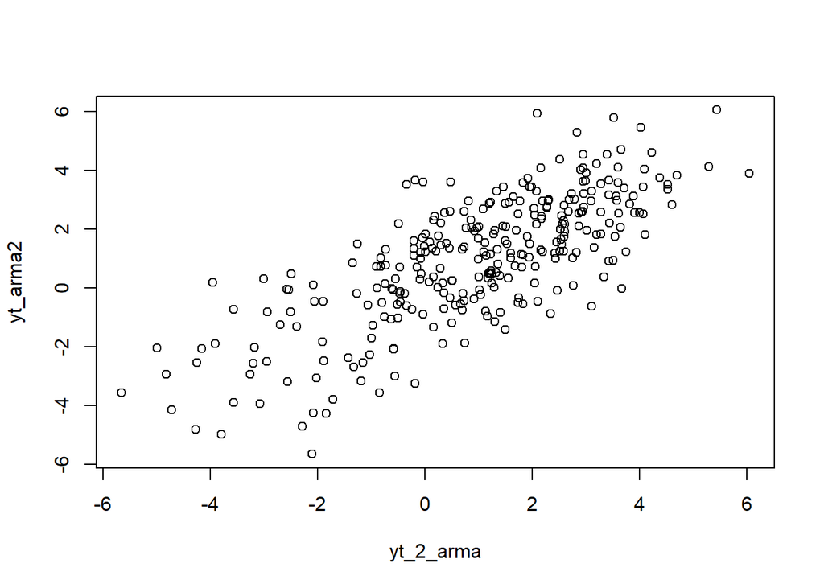

```r
plot(y=yt_arma2,x=yt_2_arma)
```

Berdasarkan scatterplot tersebut, terlihat bahwa terdapat hubungan positif antara $Y_t$ dengan $Y_{t-2}$.

```r
cor(yt_arma2,yt_2_arma)
```

```
## [1] 0.750885
```

#### Korelasi antara $Y_t$ dengan $Y_{t-3}$

```r
#Yt
yt_arma3 <- arma22[-c(1,2,3)]
yt_arma3
```

```
##   [1]  2.77087144  2.46848527  0.08051160 -0.08896032  0.20737111  0.29081568
##   [7]  1.25030893  0.66036602  0.16603416 -0.54915903 -1.34368878  0.29972269
##  [13]  0.85520458  2.19176110  2.29962173  2.94397715  2.95458866  4.53088998
##  [19]  3.61528979  3.50763361  2.54190716  0.92571838  1.64530963  1.92116502
##  [25]  3.09682123  3.72021120  2.95072468  3.39462184  4.07469797  4.53001081
##  [31]  3.43158744  3.33827762  0.91740994  0.35988571 -0.37778345 -0.72524792
##  [37] -0.19959573  0.76655190  1.59923538  2.04310024  1.02020298  0.15793833
##  [43] -0.07916799  0.36427686  1.20014599  2.55506243  2.86963228  2.46062305
##  [49]  2.52900147  1.56172045  1.99243433  2.90750126  3.43673255  4.00491492
##  [55]  2.19104871  2.56319006  1.22654492  2.16774665  2.91050629  2.43021091
##  [61]  2.57980915  0.99456172  2.27583775  0.97250839  2.73117575  2.03632154
##  [67]  3.19687834  2.69176105  4.22737770  2.99683807  4.60438773  3.64568771
##  [73]  2.82092587  2.06121940  1.19210313  0.73000077  0.50069417 -0.45388615
##  [79]  0.23601881 -0.48447030  0.01288082  2.17251217  1.22657850  2.34508754
##  [85]  1.13232799 -0.89194662 -0.80375510 -0.01571585 -0.51431008  1.41026427
```

[output cut: 35 more lines]

```r
#Yt-1
yt_3_arma <- arma22[-c(298,299,300)]
yt_3_arma
```

```
##   [1]  0.86729036  2.26983582  2.04860540  2.77087144  2.46848527  0.08051160
##   [7] -0.08896032  0.20737111  0.29081568  1.25030893  0.66036602  0.16603416
##  [13] -0.54915903 -1.34368878  0.29972269  0.85520458  2.19176110  2.29962173
##  [19]  2.94397715  2.95458866  4.53088998  3.61528979  3.50763361  2.54190716
##  [25]  0.92571838  1.64530963  1.92116502  3.09682123  3.72021120  2.95072468
##  [31]  3.39462184  4.07469797  4.53001081  3.43158744  3.33827762  0.91740994
##  [37]  0.35988571 -0.37778345 -0.72524792 -0.19959573  0.76655190  1.59923538
##  [43]  2.04310024  1.02020298  0.15793833 -0.07916799  0.36427686  1.20014599
##  [49]  2.55506243  2.86963228  2.46062305  2.52900147  1.56172045  1.99243433
##  [55]  2.90750126  3.43673255  4.00491492  2.19104871  2.56319006  1.22654492
##  [61]  2.16774665  2.91050629  2.43021091  2.57980915  0.99456172  2.27583775
##  [67]  0.97250839  2.73117575  2.03632154  3.19687834  2.69176105  4.22737770
##  [73]  2.99683807  4.60438773  3.64568771  2.82092587  2.06121940  1.19210313
##  [79]  0.73000077  0.50069417 -0.45388615  0.23601881 -0.48447030  0.01288082
##  [85]  2.17251217  1.22657850  2.34508754  1.13232799 -0.89194662 -0.80375510
```

[output cut: 35 more lines]

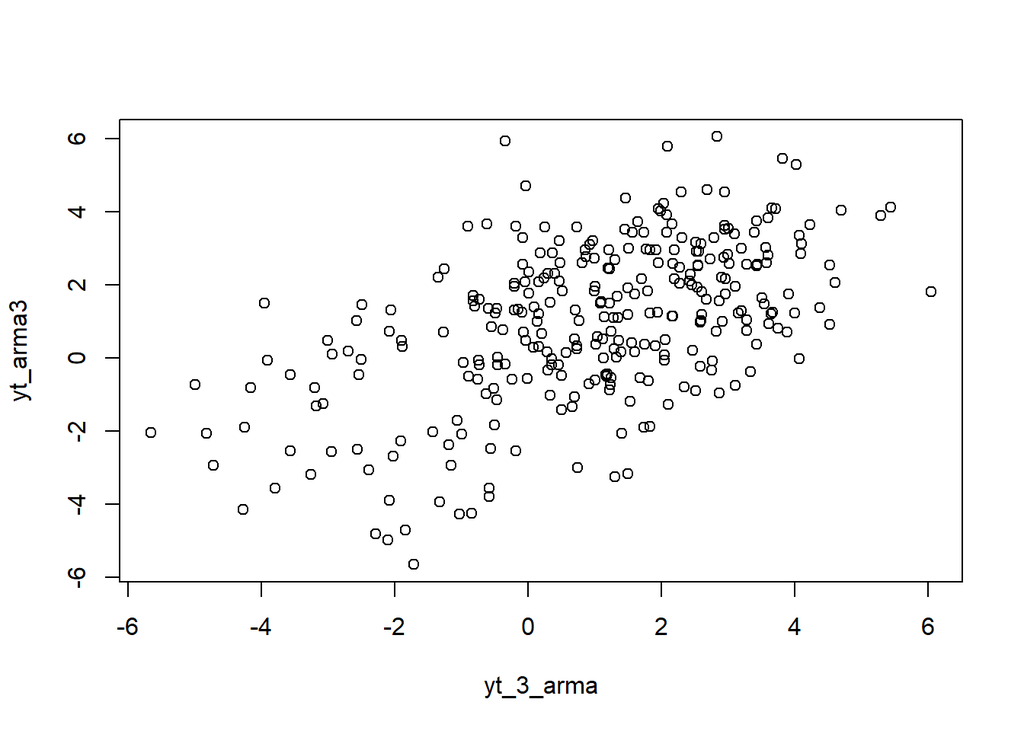

```r
plot(y=yt_arma3,x=yt_3_arma)
```

Berdasarkan scatterplot tersebut, terlihat bahwa terdapat hubungan positif antara $Y_t$ dengan $Y_{t-3}$.

```r
cor(yt_arma3,yt_3_arma)
```

```
## [1] 0.5442006
```